# Introduccion_a_R

José Fuentes

2023-10-09

# Utilizando R Markdown

```r
print("Hola mundo")
```

```
## [1] "Hola mundo"
```

```r
print('hola mundo')
```

```
## [1] "hola mundo"
```

```r
7+5
```

```
## [1] 12
```

```r
suma <- 6+7
print(suma)
```

```
## [1] 13
```

## Operador `c()` , función `seq()`

```r
vec1 <- c(1,2,3,4,5,6,7,8,9,10)
print(vec1)
```

```
##  [1]  1  2  3  4  5  6  7  8  9 10
```

```r
vecstr <- c('a','e','i', 'o')
print(vecstr)
```

```
## [1] "a" "e" "i" "o"
```

### Sintaxis Función seq: `seq(desde, hasta, incrementos)`

```r
seq(1,10,1)
```

```
##  [1]  1  2  3  4  5  6  7  8  9 10
```

Ejemplo: Elaborar una secuencia de números pares hasta 30

```r
pares <- seq(2,30, 2)
pares
```

```
##  [1]  2  4  6  8 10 12 14 16 18 20 22 24 26 28 30
```

## Otro tipo de secuencias

```r
x <- 5:10
x
```

```
## [1]  5  6  7  8  9 10
```

```r
y <- 15:20
y
```

```
## [1] 15 16 17 18 19 20
```

```r
x*y
```

```
## [1]  75  96 119 144 171 200
```

## Trabajando con un dataset `mtcars`

```r
library(dplyr)  # dentro de esta libreria se encuentra mtcars
library(explore)
```

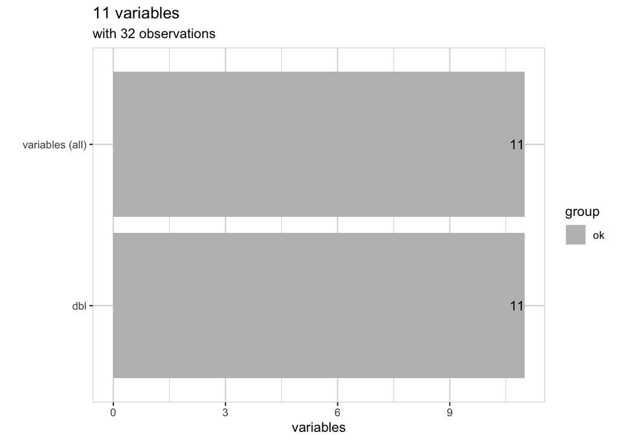

```r
mtcars %>% explore_tbl()
```

```r
mtcars %>% describe()
```

```
## # A tibble: 11 × 8
##    variable type     na na_pct unique   min   mean    max
##    <chr>    <chr> <int>  <dbl>  <int> <dbl>  <dbl>  <dbl>
##  1 mpg      dbl       0      0     25 10.4   20.1   33.9
##  2 cyl      dbl       0      0      3  4      6.19   8
##  3 disp     dbl       0      0     27 71.1  231.   472
##  4 hp       dbl       0      0     22 52    147.   335
##  5 drat     dbl       0      0     22  2.76   3.6    4.93
##  6 wt       dbl       0      0     29  1.51   3.22   5.42
##  7 qsec     dbl       0      0     30 14.5   17.8   22.9
##  8 vs       dbl       0      0      2  0      0.44   1
##  9 am       dbl       0      0      2  0      0.41   1
## 10 gear     dbl       0      0      3  3      3.69   5
## 11 carb     dbl       0      0      6  1      2.81   8
```

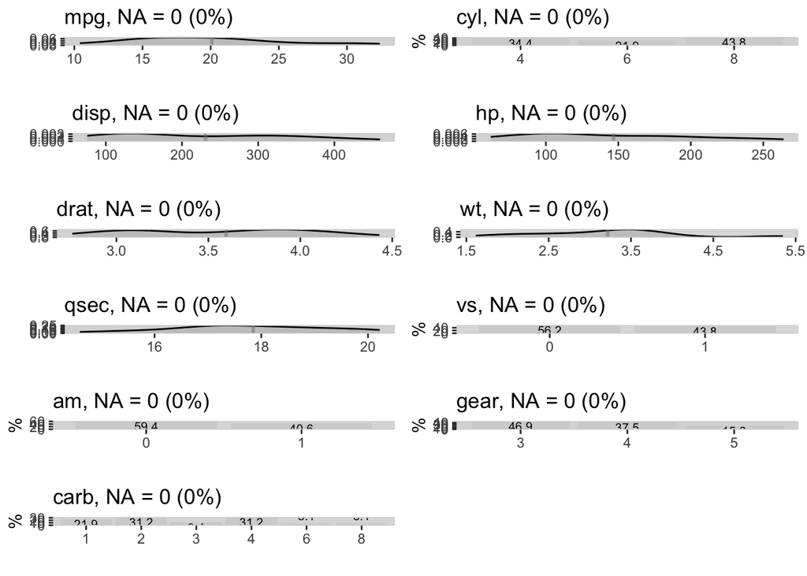

```r
mtcars %>%  explore_all()
```

## Podemos averiguar la información Grafica por caracteristica?

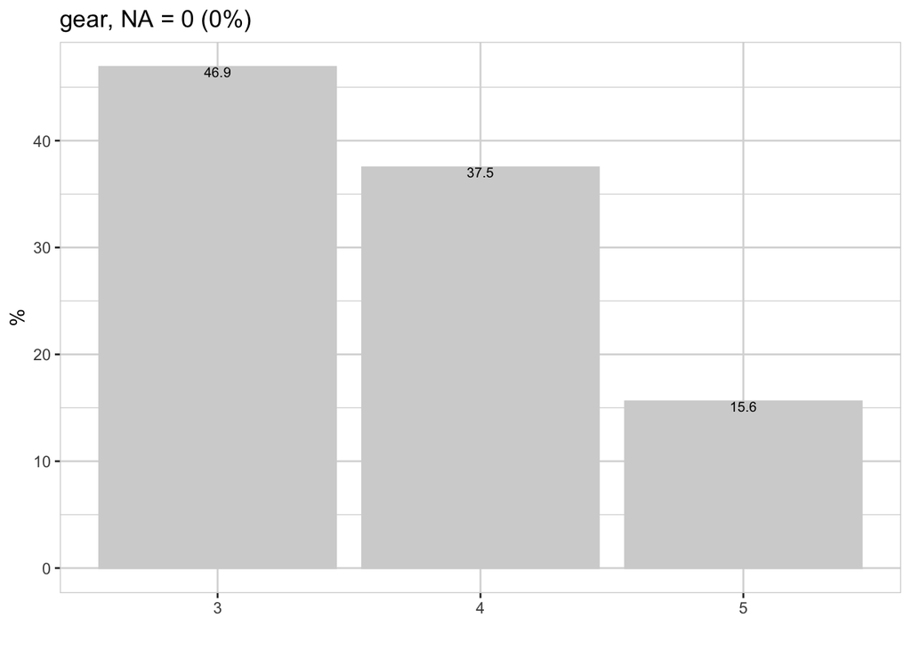

```r
mtcars %>% explore(gear)
```

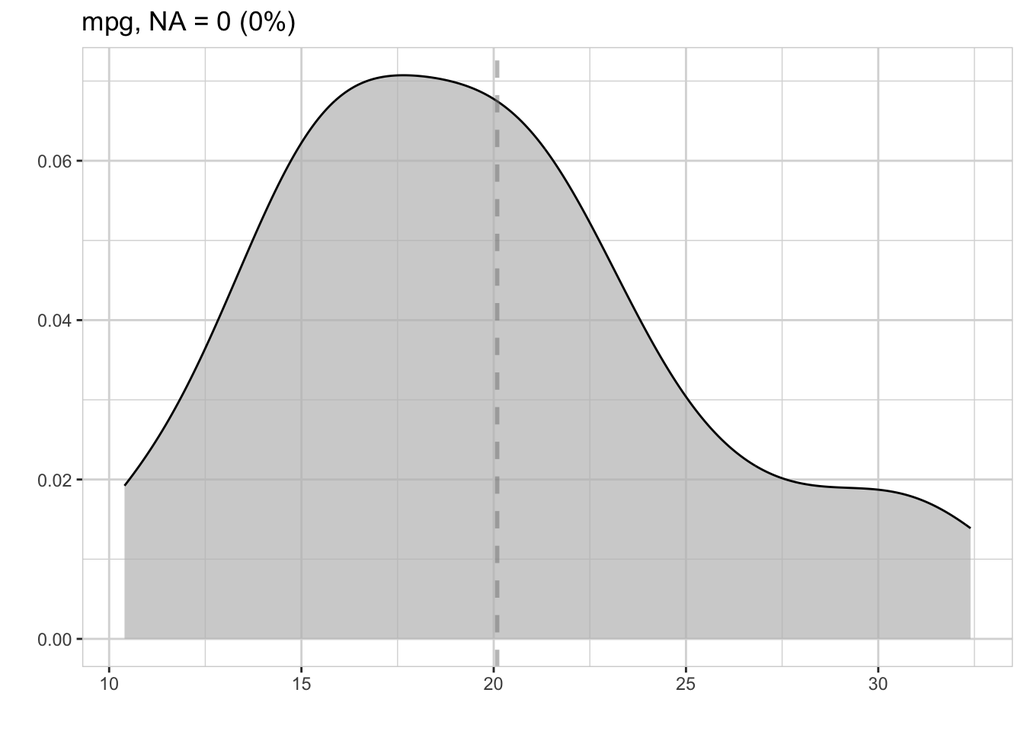

```r
mtcars %>% explore(mpg)
```

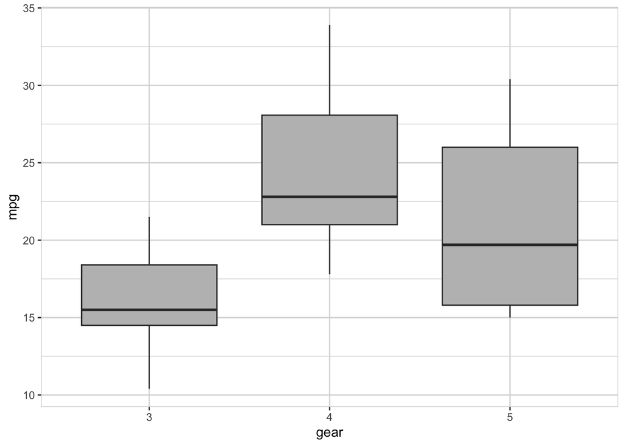

```r
mtcars %>% explore(gear, mpg)
```

### Relación de las variables

Estableciendo la relación de las variables en `gear, mpg, hp, cyl, am` con respecto a la variable `gear`

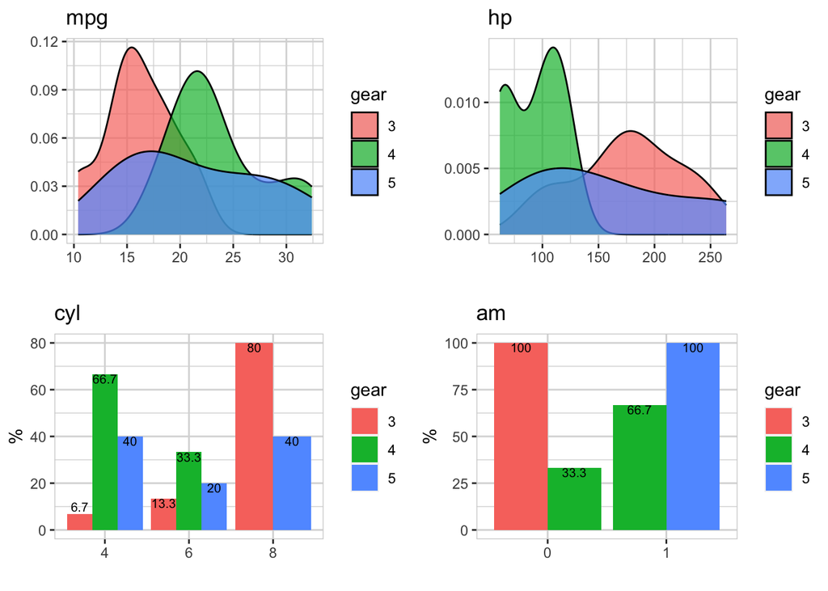

```r
mtcars %>%
  select(gear, mpg, hp, cyl, am) %>%
  explore_all(target = gear)
```

## Alto rendimiento de millas por galón

Definimos una condición para los autos que tengan en su variable mpg > 25

```r
df_opmpg <- mtcars %>%
  mutate(highmpg = if_else(mpg > 25, 1, 0, 0)) %>%
  select(-mpg)
```

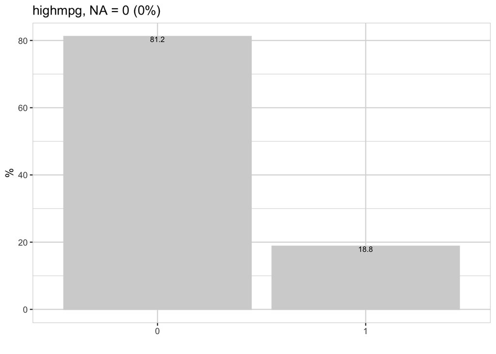

```r
library(magrittr)
df_opmpg %>%
  explore(highmpg)
```

```r
  #color(bar_color = "skyblue",
   #     text_color = "darkred")
```

Note que, alrededor de un 18.8% de autos tienen un rendimiento de mpg > 25.

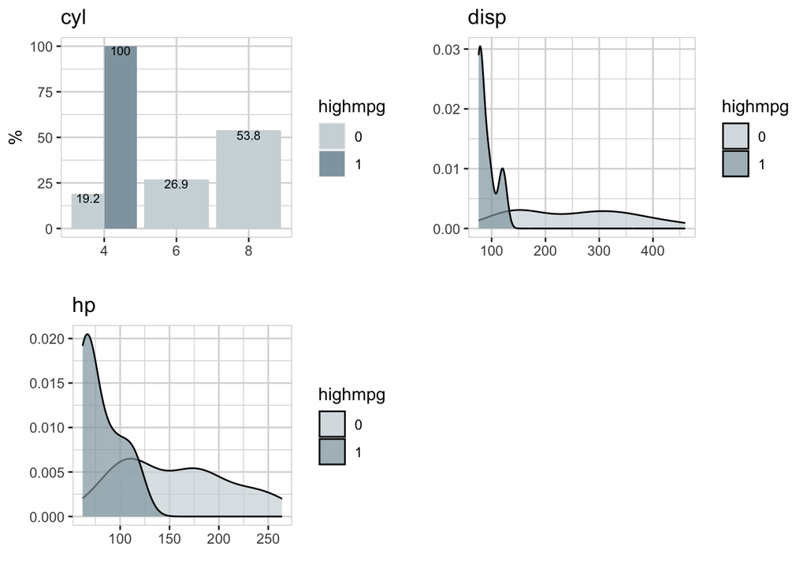

```r
df_opmpg %>%
  select(highmpg, cyl, disp, hp) %>%
  explore_all(target = highmpg)
```

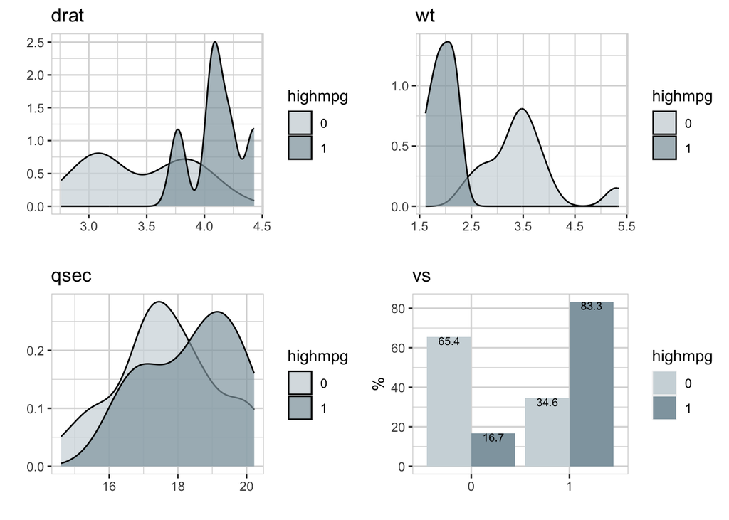

```r
df_opmpg %>%
  select(highmpg,drat,wt, qsec, vs) %>%
  explore_all(target = highmpg)
```

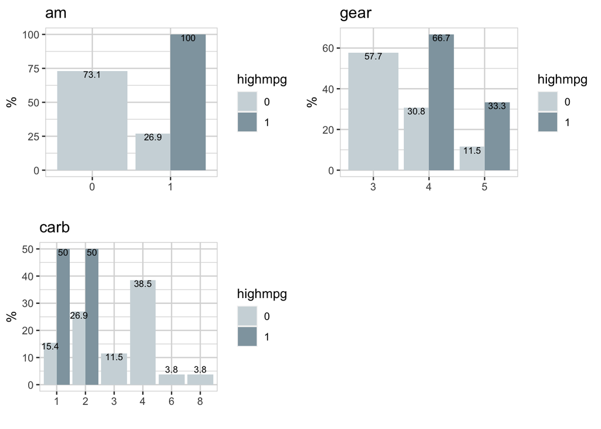

```r
df_opmpg %>%
  select(highmpg,am, gear, carb) %>%
  explore_all(target = highmpg)
```

Deseamos segmentar la relación entre carros con “*alto o bajo highmpg*”

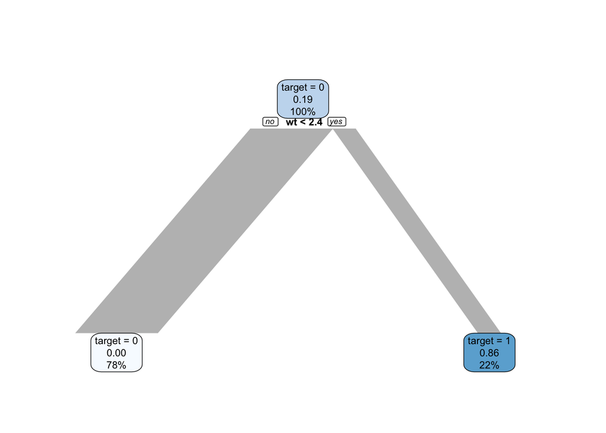

```r
df_opmpg %>% explain_tree(target = highmpg)
```

El árbol de decisión nos muestra la variable que esta fuertemente relacionada con el *highmpg* dicha varibale es la de peso *wt*.

### Que significa?

Esto explica que los autos que tienen menos peso, tienden a tener alto rendimiento en millas por galón *Highmpg*.

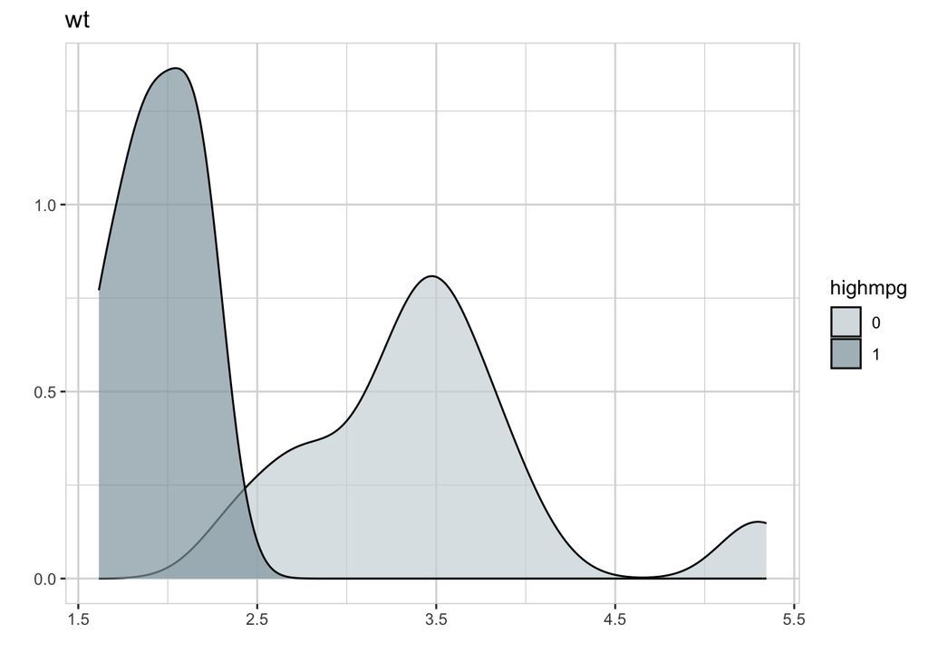

```r
df_opmpg %>% explore(wt, target = highmpg)
```

## Graficar porcentajes de carros con `"highmpg"` en función de su peso.

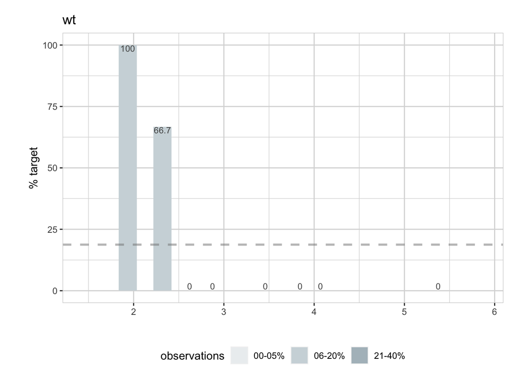

```r
df_opmpg %>% explore(wt, target = highmpg, split = FALSE )
```

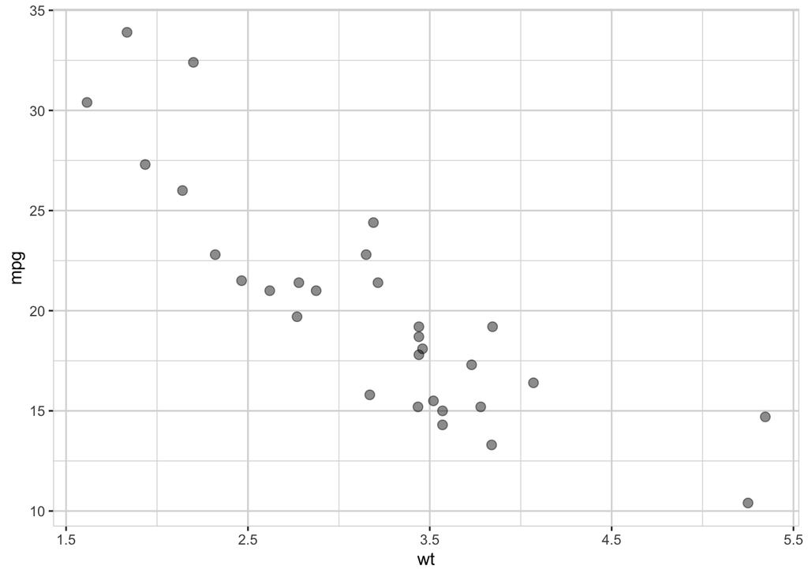

```r
mtcars %>% explore(wt, mpg)
```

Observamos en la gráfica que mientras mas peso tiene el carro mas bajo es el rendimiento de mpg.

```r
corr <-  cor(mtcars$wt,mtcars$mpg)
corr
```

```
## [1] -0.8676594
```

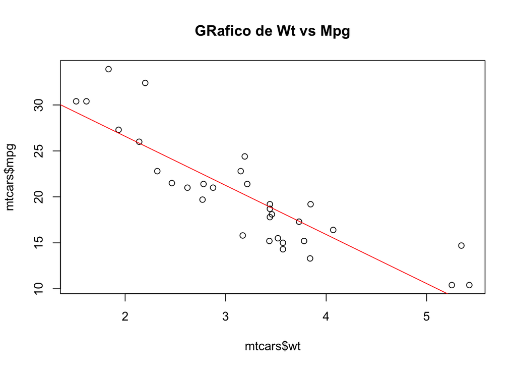

```r
plot(mtcars$wt,mtcars$mpg, main = "GRafico de Wt vs Mpg")
abline(lm(mpg~wt, data = mtcars), col="red")
```

## Existe Otra Relación?

### HorsePower

verifiquemos algunas correlaciones de las variables del dataset con HP

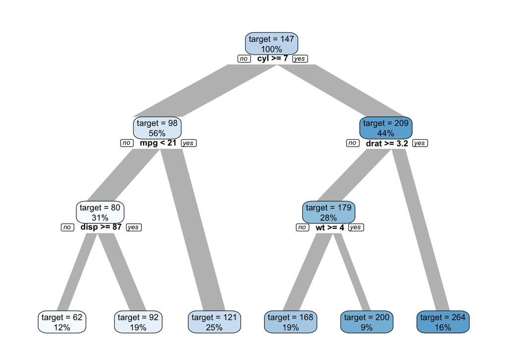

```r
mtcars %>% explain_tree(target = hp, minsplit = 9)
```

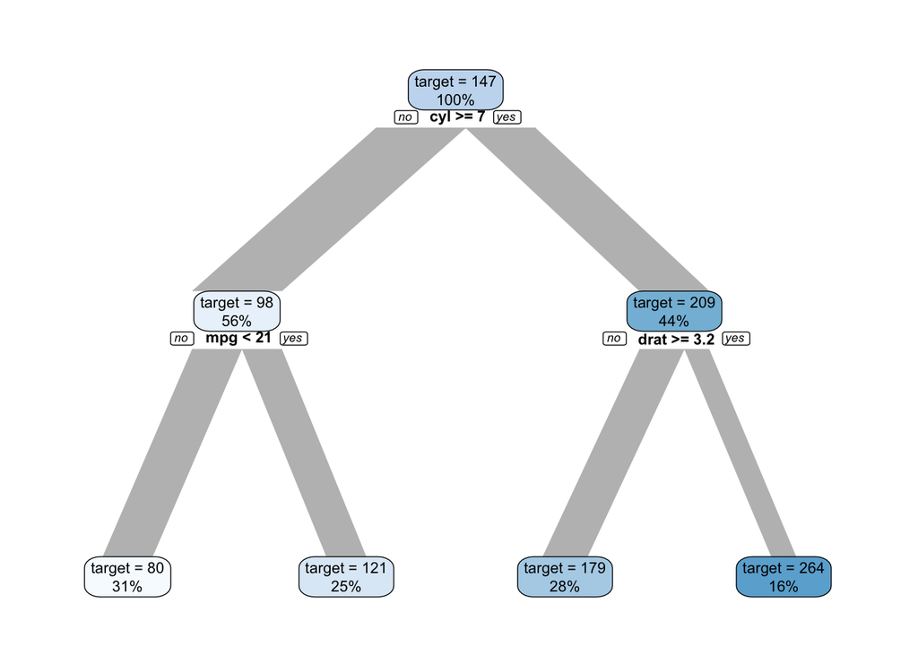

```r
mtcars %>% explain_tree(target = hp, minsplit = 11)
```

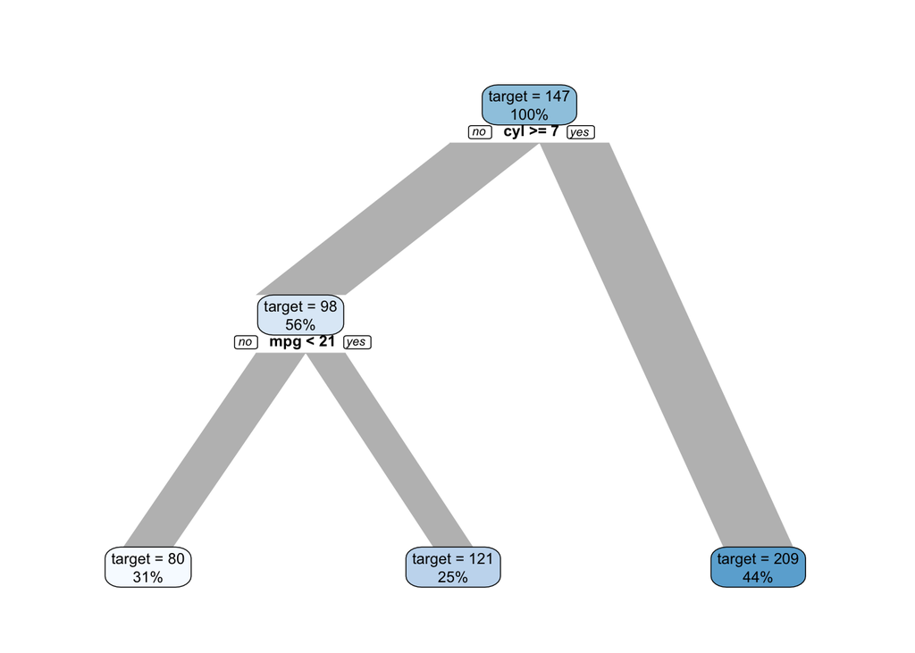

```r
mtcars %>% explain_tree(target = hp, minsplit = 15)
```

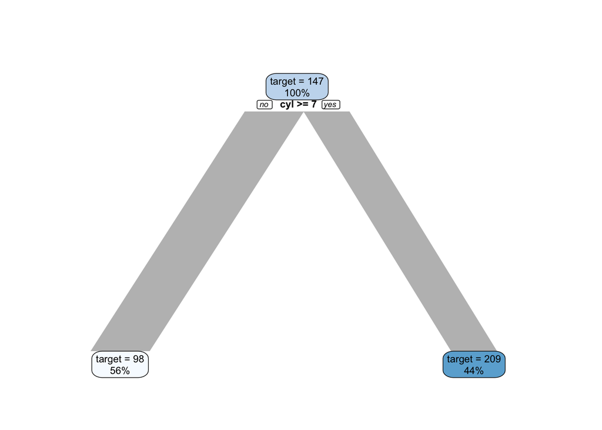

```r
mtcars %>% explain_tree(target = hp, minsplit = 20)
```

```r
model <- mtcars %>%
  explain_tree(target = hp, minsplit = 11, out = "model")
```

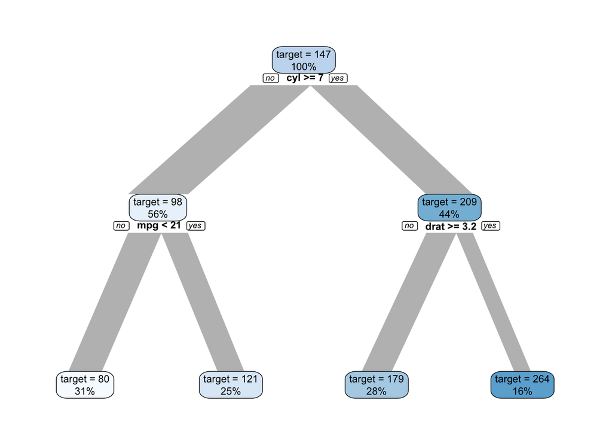

```r
model
```

```
## n= 32
##
## node), split, n, deviance, yval
##       * denotes terminal node
##
## 1) root 32 145726.900 146.68750
##   2) cyl< 7 18  14638.940  98.05556
##     4) mpg>=21.45 10   3618.000  80.00000 *
##     5) mpg< 21.45 8   3685.875 120.62500 *
##   3) cyl>=7 14  33782.360 209.21430
##     6) drat< 3.18 9   3688.889 178.88890 *
##     7) drat>=3.18 5   6918.800 263.80000 *
```

```r
model <- mtcars %>%
  explain_tree(target = hp, minsplit = 15, out = "model")
```

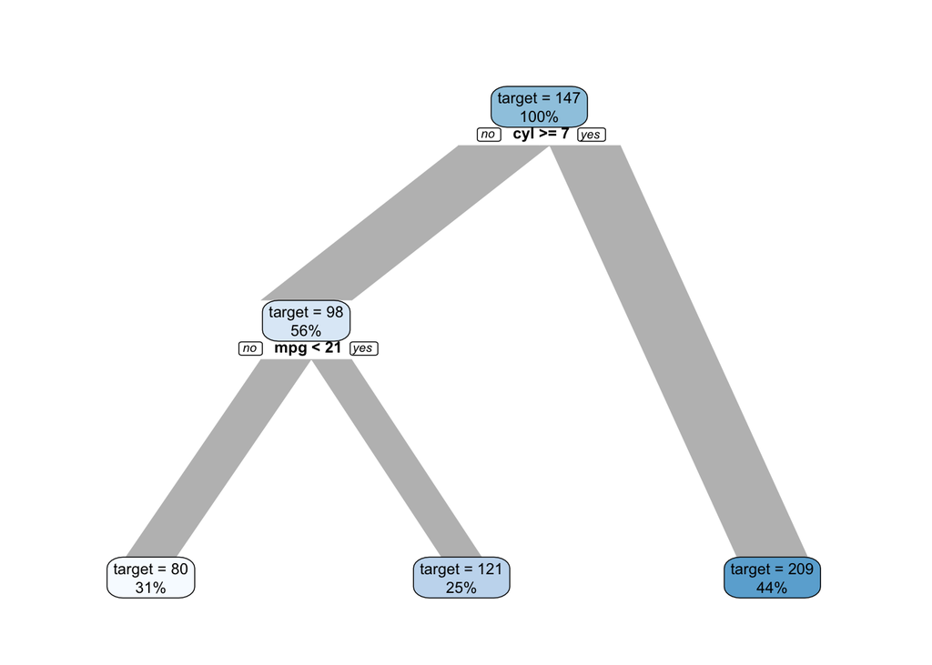

```r
model
```

```
## n= 32
##
## node), split, n, deviance, yval
##       * denotes terminal node
##
## 1) root 32 145726.900 146.68750
##   2) cyl< 7 18  14638.940  98.05556
##     4) mpg>=21.45 10   3618.000  80.00000 *
##     5) mpg< 21.45 8   3685.875 120.62500 *
##   3) cyl>=7 14  33782.360 209.21430 *
```

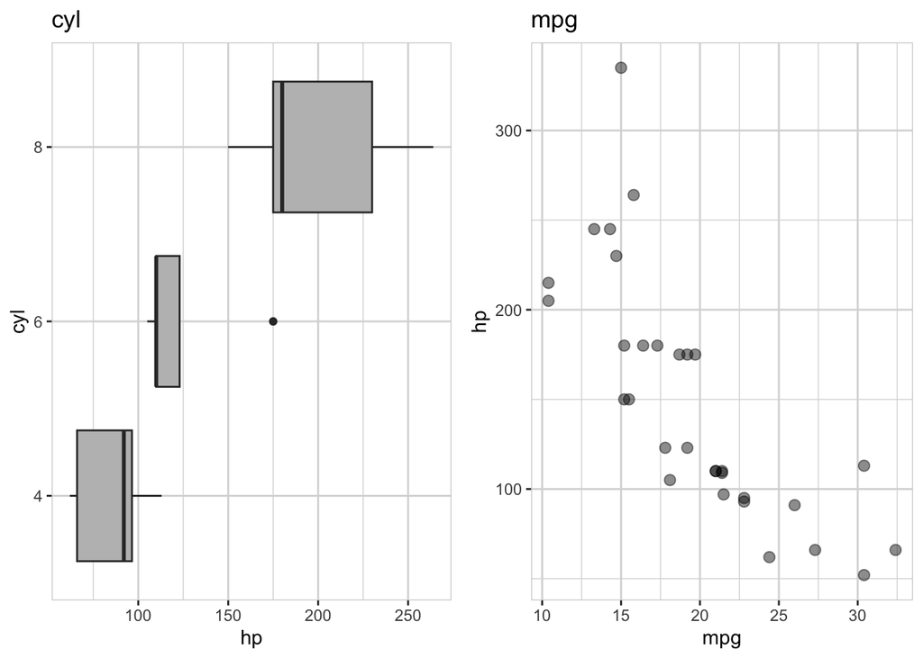

```r
mtcars %>%
  select(hp,cyl, mpg) %>%
  explore_all(target =  hp)
```

Observaciones: 1- Los carros de 8 cilindros tienen mayor Horse Power. 2- Los carro con bajo mpg tienen también alto hp.